# Homework 8

Jake Hiltscher

## Data and Description

Bike sharing systems are the new generation of traditional bike rentals where the process from membership, rental and return back has become automatic. Through these systems, users are able to easily rent a bike from a particular position and return back at another position. Currently, there are about over 500 bikesharing programs around the world which is composed of over 500,000 bicycles. Today, there exists great interest in these systems due to their important role in traffic, environmental and health issues.

The bike-sharing rental process is highly correlated with environmental and seasonal settings. For instance, weather conditions, precipitation, day of week, season, hour of the day, etc. can affect the volume of rentals. This dataset is composed from the two-year historical data corresponding to years 2011 and 2012 from the Capital Bikeshare system in Washington D.C. The daily counts of the number of bikes used was extracted and then the corresponding weather and seasonal information was added.

The data set has information for 731 days and contains the following variables:

| Variable | Description |
| --- | --- |
| season | Season (Fall, Spring, Summer, Winter) |
| yr | Year (2011, 2012) |
| holiday | Was the day a holiday (Yes/No)? |
| workingday | Was the day a working day (Yes/No)? (Yes if the day is neither a weekend nor a holiday) |
| weathersit | Weather (Clear, Light Precip, Misty) |
| temp | Normalized temperature in Celsius |
| hum | Normalized humidity |
| windspeed | Normalized windspeed |
| cnt | Number of bikes rented |

The data can be found in the Bikes data set on Canvas. Download Bikes.csv, and put it in the same folder as this R Markdown file.

#### 0. Replace the text “< PUT YOUR NAME HERE >” (above next to “author:”) with your full name.

#### 1. Read in the data set, and call the data frame “bikes”. Make sure the yr and character variables are factors (if they are not, you’ll need to make them factors). Print a summary of the data and make sure the data makes sense.

```r
bikes <- read_csv("Bikes.csv") %>%
  mutate_if(is.character, as.factor) %>% mutate(yr = as.factor(yr))
summary(bikes)
```

```
##     season       yr      holiday   workingday        weathersit
##  Fall  :188   2011:365   No :710   No :231    Clear       :463
##  Spring:181   2012:366   Yes: 21   Yes:500    Light Precip: 21
##  Summer:184                                   Misty       :247
##  Winter:178
##
##
##       temp              hum           windspeed            cnt
##  Min.   :0.05913   Min.   :0.0000   Min.   :0.02239   Min.   :  22
##  1st Qu.:0.33708   1st Qu.:0.5200   1st Qu.:0.13495   1st Qu.:3152
##  Median :0.49833   Median :0.6267   Median :0.18097   Median :4548
##  Mean   :0.49538   Mean   :0.6279   Mean   :0.19049   Mean   :4504
##  3rd Qu.:0.65542   3rd Qu.:0.7302   3rd Qu.:0.23321   3rd Qu.:5956
##  Max.   :0.86167   Max.   :0.9725   Max.   :0.50746   Max.   :8714
```

#### 2. Explore the data: create a histogram for the response. *Briefly describe the shape of the distribution - you should mention (1) symmetry or skewness, (2) the number of modes, and (3) potential outliers.*

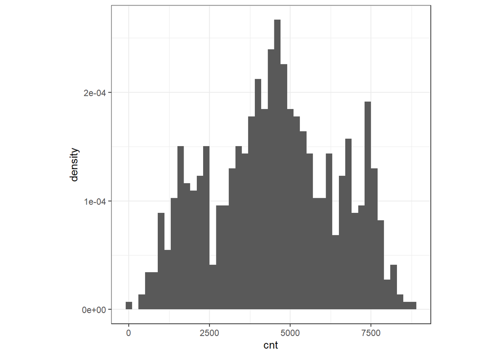

```r
bikes_hist <- ggplot(data = bikes) +
  geom_histogram(mapping = aes(x = cnt, y = ..density..),
                 binwidth = 200) +
  theme_bw() +
  theme(aspect.ratio = 1)
bikes_hist
```

The histogram is pretty symmetrical, even with the two “bumps” on both sides. There’s three modes in the graph. I think there’s an outlierr at around 0 but it’s hard to tell, I would need another graphic to look into it more.

#### 3. Briefly explain why traditional multiple linear regression methods are not suitable for *this* data set. You should mention at least two of the reasons we discussed in class (*your reasons should refer to this data set (i.e. be specific, not general)*).

Traditional multiple linear regression wouldn’t work as well as Poisson because there are multiple categorical factors that will lead to homoscedasticity and errors won’t be normally distributed.

#### 4. Use a variable selection procedure to help you decide which, if any, variables to omit from the Poisson regression model you will soon fit. You may choose which selection method to use (best subsets, forward, backward, sequential replacement, LASSO, or elastic net) and which metric/criteria to use (AIC, BIC, or CV/PMSE).

```r
bikes_best_subsets_bic <- bestglm(as.data.frame(bikes),
                                  IC = "BIC",
                                  method = "exhaustive",
                                  TopModels = 1,
                                  family = poisson)
```

```
## Morgan-Tatar search since family is non-gaussian.
```

```
## Note: factors present with more than 2 levels.
```

```r
summary(bikes_best_subsets_bic$BestModel)
```

```
##
## Call:
## glm(formula = y ~ ., family = family, data = Xi, weights = weights)
##
## Deviance Residuals:
##     Min       1Q   Median       3Q      Max
## -70.265   -7.857    1.294    7.716   55.510
##
## Coefficients:
##                         Estimate Std. Error z value Pr(>|z|)
## (Intercept)             7.782966   0.005420 1435.88   <2e-16 ***
## seasonSpring           -0.252280   0.002836  -88.96   <2e-16 ***
## seasonSummer            0.091761   0.001666   55.08   <2e-16 ***
## seasonWinter            0.211052   0.002179   96.86   <2e-16 ***
## yr2012                  0.459285   0.001152  398.71   <2e-16 ***
## holidayYes             -0.165426   0.003727  -44.39   <2e-16 ***
## workingdayYes           0.025368   0.001237   20.51   <2e-16 ***
## weathersitLight Precip -0.732487   0.005498 -133.22   <2e-16 ***
## weathersitMisty        -0.102136   0.001500  -68.08   <2e-16 ***
## temp                    1.221423   0.005702  214.21   <2e-16 ***
## hum                    -0.245916   0.005565  -44.19   <2e-16 ***
## windspeed              -0.574127   0.008107  -70.82   <2e-16 ***
## ---
## Signif. codes:  0 '***' 0.001 '**' 0.01 '*' 0.05 '.' 0.1 ' ' 1
##
## (Dispersion parameter for poisson family taken to be 1)
##
##     Null deviance: 668801  on 730  degrees of freedom
## Residual deviance: 132657  on 719  degrees of freedom
## AIC: 140079
##
## Number of Fisher Scoring iterations: 4
```

#### 6. Fit a Poisson regression model using the covariates that you used in the previous question (use the `glm` function - do not just call the result from the variable selection procedure). Print a summary of the results.

```r
bikes_poisson <- glm(cnt ~ ., family = poisson, data = bikes)

summary(bikes_poisson)
```

```
##
## Call:
## glm(formula = cnt ~ ., family = poisson, data = bikes)
##
## Deviance Residuals:
##     Min       1Q   Median       3Q      Max
## -70.265   -7.857    1.294    7.716   55.510
##
## Coefficients:
##                         Estimate Std. Error z value Pr(>|z|)
## (Intercept)             7.782966   0.005420 1435.88   <2e-16 ***
## seasonSpring           -0.252280   0.002836  -88.96   <2e-16 ***
## seasonSummer            0.091761   0.001666   55.08   <2e-16 ***
## seasonWinter            0.211052   0.002179   96.86   <2e-16 ***
## yr2012                  0.459285   0.001152  398.71   <2e-16 ***
## holidayYes             -0.165426   0.003727  -44.39   <2e-16 ***
## workingdayYes           0.025368   0.001237   20.51   <2e-16 ***
## weathersitLight Precip -0.732487   0.005498 -133.22   <2e-16 ***
## weathersitMisty        -0.102136   0.001500  -68.08   <2e-16 ***
## temp                    1.221423   0.005702  214.21   <2e-16 ***
## hum                    -0.245916   0.005565  -44.19   <2e-16 ***
## windspeed              -0.574127   0.008107  -70.82   <2e-16 ***
## ---
## Signif. codes:  0 '***' 0.001 '**' 0.01 '*' 0.05 '.' 0.1 ' ' 1
##
## (Dispersion parameter for poisson family taken to be 1)
##
##     Null deviance: 668801  on 730  degrees of freedom
## Residual deviance: 132657  on 719  degrees of freedom
## AIC: 140079
##
## Number of Fisher Scoring iterations: 4
```

### The next several questions involve using diagnostics to check the Poisson regression model assumptions. For each assumption, (1) code the diagnostic(s) that I indicate (next to the assumption in parentheses) to determine if the assumption is violated, and (2) explain whether or not you think the assumption is violated and why you think that.

#### 7. The X’s vs log(y) are linear (use scatterplots and partial regression (added-variable) plots)

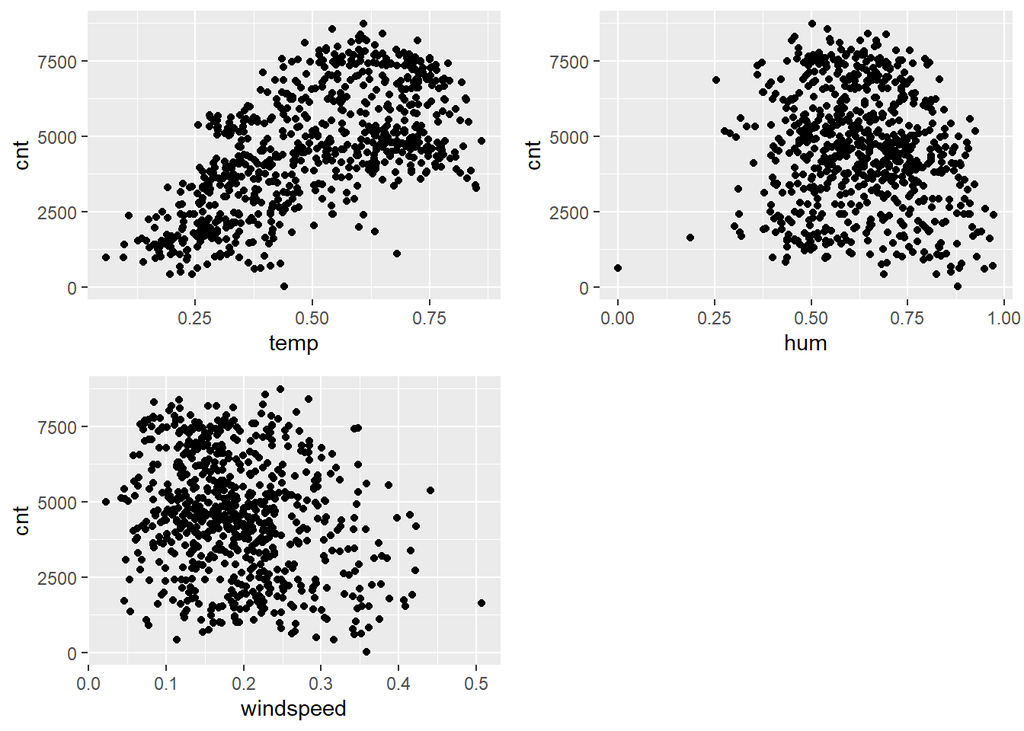

```r
scatter_temp <- ggplot(bikes, aes(temp, cnt)) +
  geom_point()

scatter_hum <- ggplot(bikes, aes(hum, cnt)) +
  geom_point()

scatter_windspeed <- ggplot(bikes, aes(windspeed, cnt)) +
  geom_point()

grid.arrange(scatter_temp,
             scatter_hum,
             scatter_windspeed,
             nrow = 2)
```

Temp has a curve to it, hum and windspeed seem to be random. I would say this assumption is met.

#### 8. The residuals are independent (no diagnostic tools - just think about how the data was collected and briefly write your thoughts)

This assumption is met. There isn’t any skewness or anything that would affect the data.

#### 9. The model describes all observations (i.e., there are no influential points) (use DFFITS)

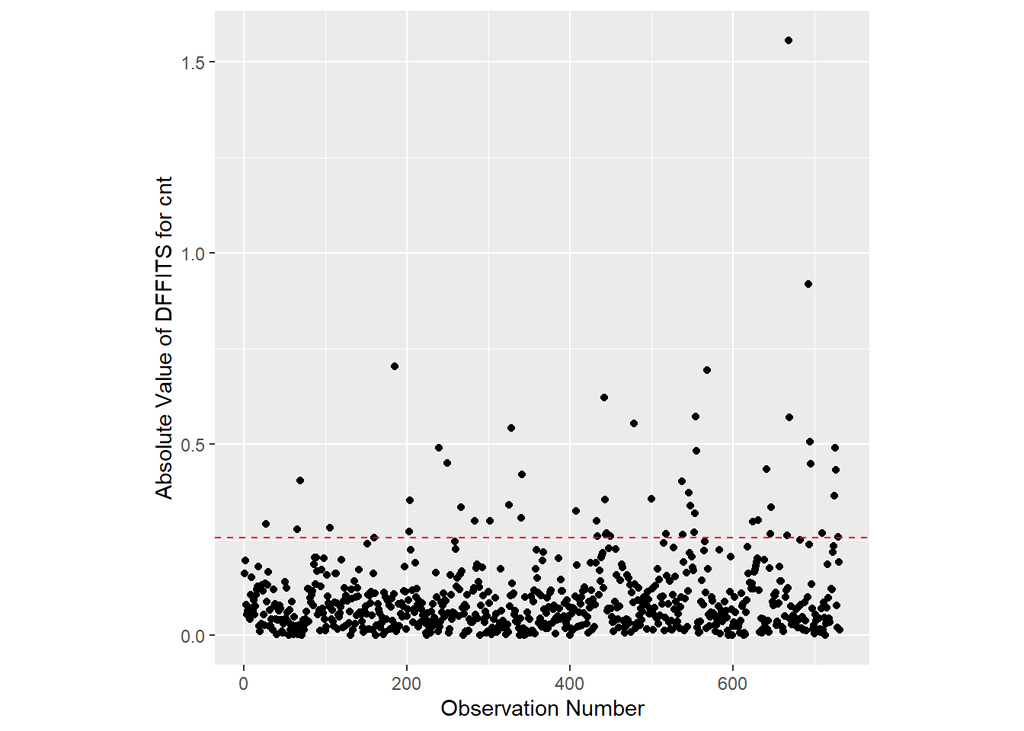

```r
bikes$dffits <- dffits(bikes_poisson)

 ggplot(data = bikes) +
   geom_point(mapping = aes(x = as.numeric(rownames(bikes)),
                            y = abs(dffits))) +
   ylab("Absolute Value of DFFITS for cnt") +
   xlab("Observation Number") +
   # for n > 30
   geom_hline(mapping = aes(yintercept = 2 * sqrt(length(bikes_poisson$coefficients) /
                                                    length(dffits))),
              color = "red",
              linetype = "dashed") +
   theme(aspect.ratio = 1)
```

#### 10. Additional predictor variables are not required (no diagnostic tools - just think about the variables you have and if there are other variables you think would help predict the response)

I think there could be something else that could effect the bike rentals, like location of the store. It effect weather and season (winter isn’t really winter in California).

#### 11. No multicollinearity (use variance inflation factors)

```r
vif(bikes_poisson)
```

```
##                GVIF Df GVIF^(1/(2*Df))
## season     3.328584  3        1.221921
## yr         1.026770  1        1.013297
## holiday    1.063467  1        1.031245
## workingday 1.065146  1        1.032059
## weathersit 1.659066  2        1.134922
## temp       3.207393  1        1.790920
## hum        1.790462  1        1.338082
## windspeed  1.166473  1        1.080034
```

The mean is less than 2 and the max value is < 10 so there is no multicollinearity.

#### 12. Mean = Variance (no overdispersion/underdispersion) (use the three methods discussed in class)

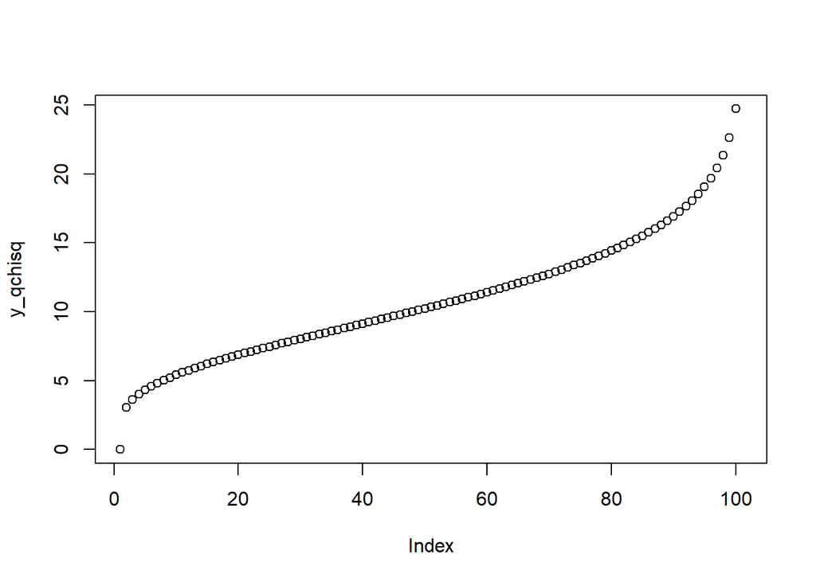

```r
# your code here
x_qchisq <- seq(0, 1, by = 0.01)
y_qchisq <- qchisq(x_qchisq, df = 11)  # Apply qchisq function
plot(y_qchisq)
```

```r
model_2 <- update(bikes_poisson, .~. - temp)
anova(model_2, bikes_poisson, test="Chisq")
```

```
## Analysis of Deviance Table
##
## Model 1: cnt ~ season + yr + holiday + workingday + weathersit + hum +
##     windspeed
## Model 2: cnt ~ season + yr + holiday + workingday + weathersit + temp +
##     hum + windspeed
##   Resid. Df Resid. Dev Df Deviance  Pr(>Chi)
## 1       720     178469
## 2       719     132657  1    45813 < 2.2e-16 ***
## ---
## Signif. codes:  0 '***' 0.001 '**' 0.01 '*' 0.05 '.' 0.1 ' ' 1
```

```r
bikes_quasi <- glm(cnt ~ ., family = quasipoisson, data = bikes)
summary(bikes_quasi)
```

```
##
## Call:
## glm(formula = cnt ~ ., family = quasipoisson, data = bikes)
##
## Deviance Residuals:
##      Min        1Q    Median        3Q       Max
## -30.2319   -1.7065    0.1999    2.1790   29.8448
##
## Coefficients:
##                         Estimate Std. Error t value Pr(>|t|)
## (Intercept)             7.734573   0.024873 310.968  < 2e-16 ***
## seasonSpring           -0.251433   0.012607 -19.944  < 2e-16 ***
## seasonSummer            0.106290   0.007564  14.053  < 2e-16 ***
## seasonWinter            0.230050   0.009771  23.545  < 2e-16 ***
## yr2012                  0.459332   0.005282  86.962  < 2e-16 ***
## holidayYes             -0.269315   0.017236 -15.625  < 2e-16 ***
## workingdayYes           0.037547   0.005676   6.615 7.26e-11 ***
## weathersitLight Precip -0.880384   0.025511 -34.509  < 2e-16 ***
## weathersitMisty        -0.109603   0.006798 -16.123  < 2e-16 ***
## temp                    1.314142   0.026485  49.618  < 2e-16 ***
## hum                    -0.279451   0.025850 -10.811  < 2e-16 ***
## windspeed              -0.586459   0.037251 -15.743  < 2e-16 ***
## dffits                  1.402947   0.019452  72.122  < 2e-16 ***
## ---
## Signif. codes:  0 '***' 0.001 '**' 0.01 '*' 0.05 '.' 0.1 ' ' 1
##
## (Dispersion parameter for quasipoisson family taken to be 20.99149)
##
##     Null deviance: 668801  on 730  degrees of freedom
## Residual deviance:  15777  on 718  degrees of freedom
## AIC: NA
##
## Number of Fisher Scoring iterations: 4
```

There is over dispersion because 20.99 is >> 1.

### Regardless of your assessment of the assumptions, proceed as if all assumptions were met.

#### 13. For the coefficient for holiday, compute (and output) $\beta_{holiday}$ (pull this value from the model output), $\exp\{\beta_{holiday}\}$, and $100 \times (\exp\{\beta_{holiday}\} - 1)%$.

```r
beta_holiday <- bikes_poisson$coefficients["holidayYes"]
beta_holiday
```

```
## holidayYes
## -0.1654263
```

```r
1/exp(beta_holiday)
```

```
## holidayYes
##   1.179896
```

```r
100 * (1/exp(beta_holiday)-1)
```

```
## holidayYes
##    17.9896
```

```r
confint(bikes_poisson, level = 0.95)
```

```
##                              2.5 %      97.5 %
## (Intercept)             7.77234123  7.79358864
## seasonSpring           -0.25783899 -0.24672263
## seasonSummer            0.08849507  0.09502590
## seasonWinter            0.20678136  0.21532225
## yr2012                  0.45702706  0.46154254
## holidayYes             -0.17273827 -0.15812925
## workingdayYes           0.02294406  0.02779195
## weathersitLight Precip -0.74327923 -0.72172503
## weathersitMisty        -0.10507676 -0.09919624
## temp                    1.21024748  1.23259907
## hum                    -0.25682323 -0.23500777
## windspeed              -0.59001718 -0.55823982
```

#### 16. Interpret the 95% confidence intervals for temp for $\beta_{temp}$, $\exp\{\beta_{temp}\}$, and $100 \times (\exp\{\beta_{temp}\} - 1)%$ (three interpretations total).

*Interpretation using $\exp\{\beta_{temp}\}$:* Holding all else constant, the average number of rented bikes increase between exp(1.21)=3.35 and exp(1.23)=3.42 as temperature increases by 1 unit.

```r
predict(bikes_poisson,
        newdata = data.frame(season = "Spring", yr = "2012", holiday = "No", workingday = "Yes", weathersit = "Misty", temp = 0.34, hum = 0.80, windspeed = 0.18),
        level = 0.95,
        interval = "confidence",
        type = "response")
```

```
##       1
## 3066.86
```

#### 18. Compute (and output) the likelihood ratio test statistic for the model, and compute (and output) the associated $p$-value. Based on the results, what do you conclude?

```r
full_model <- glm(cnt ~ ., data = bikes)
lr.stat <- lrtest(full_model, bikes_poisson)
lr.stat
```

```
## Likelihood ratio test
##
## Model 1: cnt ~ season + yr + holiday + workingday + weathersit + temp +
##     hum + windspeed + dffits
## Model 2: cnt ~ season + yr + holiday + workingday + weathersit + temp +
##     hum + windspeed
##   #Df LogLik Df  Chisq Pr(>Chisq)
## 1  14  -5517
## 2  12 -70028 -2 129022  < 2.2e-16 ***
## ---
## Signif. codes:  0 '***' 0.001 '**' 0.01 '*' 0.05 '.' 0.1 ' ' 1
```

#### 19. Compute (and output) the pseudo $R^2$ value for the model.

```r
with(summary(bikes_poisson), 1-deviance/null.deviance)
```

```
## [1] 0.8016502
```

#### 20. Briefly summarize what you learned, personally, from this analysis about the statistics, model fitting process, etc.

I find it interesting in the data that none of the variables were dropped with best subset. I think it’s a rare thing to have it all line up like that.

#### 21. Briefly summarize what you learned from this analysis *to a non-statistician*. Write a few sentences about (1) the purpose of this data set and analysis and (2) what you learned about this data set from your analysis. Write your response as if you were addressing a business manager (avoid using statistics jargon) and just provide the main take-aways.

The dataset and analysis purpose is to show what influences the number of bike rentals.